# meta-analysis-w-data

Emily Wissel

2024-08-01

## Meta-Analysis of Untargetted Metabolomics from Heart Failure Patients

This RMarkdown script serves as an analysis of the metabolomics data downloaded from previously published studies. The data to be included in this analysis had to meet the following criteria:

1. Be a study of adult humans with heart failure
   - studies of children or of patients at risk for heart failure were disqualified
2. Conduct untargetted metabolomics
   - any sample type (plasma, serum, stool, etc.) is included
   - any metabolomics method is included so long as it is untargeted
3. Have publicly available data
   - the data must be published to a public repository, like MetaboLights.
   - specifically, we selected studies that had processed data published as that data (theoretically) has been compared to internal standards for peak-normalization / identification, whereas this quality control step is impossible with publicly available raw data without co-published internal standards

#### Screening process

Let’s review how many papers qualified out of our total number of papers screened for this meta-analysis and systematic review.

All of the researchers worked very hard to screen all 700 or so papers, so big thank you to everyone who participated in this project. Screeners had to contact me to receive additional citations once they completed the list previously sent to them, with 20-50 citations being sent to each person at a time (with the exception of Kiramat who had about 120 citations sent to him early on in the project).

Jack and Leie both completed many citation screenings, with Jack completing the most at 195 papers screened (vs 188 for Leise). This is followed by YiChan who completed 155 and Kiramat who completed 124 paper.

For systematic reviews, you typically expect an error rate of ~5% per person. This means that when combining the results across screeners, we expect a ~9.5% mismatch rate. For our study, we actually found the mismatch rate to be much lower (comparing me to each reviewer). YiChan and I had a 5.6% mismatch rate, with Leise 5.3%, Kiramat 4.0%, and Jack 2.1%. I find these rates very impressive, and also indicative of everyone putting a lot of care into their screening of these papers. Thank you again to everyone for completing this on top of your normal duties with such diligence.

Let’s dig deeper into the papers that didn’t make it (since most of them did not qualify for inclusion):

```r
dat_plot <- places1 %>% ungroup() %>% select(heart_failure_yn, human_yn,metabolomics_yn, data_availability )
## plot

mydat <- dat_plot %>%
  make_long(heart_failure_yn, human_yn,metabolomics_yn, data_availability )
reagg <- mydat %>%
  dplyr::group_by(node)%>%  # Here we are grouping the data by node and then we are taking the frequency of it
  tally()
mydat2 <- merge(mydat,
             reagg,
             by.x = 'node',
             by.y = 'node',
             all.x = TRUE)
mydat2 %>%
  ggplot(aes(x = x,
             next_x = next_x,
             node = node,
             next_node = next_node,
             fill = factor(node),
             label = paste0(node, " = ", n))) +           # This Creates a label for each node) +
  geom_sankey(flow.alpha = 0.5,          #This Creates the transparency of your node
                      node.color = "black",     # This is your node color
                      show.legend = FALSE) +
  geom_sankey_label(size = 4, fill = "white") + # specifies the Label node
  theme_bw() +
  theme(axis.title = element_blank(),
        axis.text.x = element_blank(),
        axis.text.y = element_blank(),
                 axis.ticks = element_blank(),
                 panel.grid = element_blank() ) +
  theme(legend.position = 'none') +

  scale_fill_viridis_d(option = "inferno")+
  labs(title = "Systematic Review: Screening Results")
print("Not shown are the articles not in English.")
```

[output not shown]

lets look at papers that nearly qualified

```r
lilb <- dat_secondary1 %>%
    filter(reviewer != "EW" & reviewer != "Ew" & reviewer != "ew" & reviewer != "EW " & reviewer != " EW" & reviewer != "English")
table(lilb$heart_failure_yn)
lilb2 <- lilb %>% filter(heart_failure_yn == "Yes, study of heart failure.")
table(lilb2$human_yn)
lilb3 <- lilb2 %>% filter(human_yn== "yes, human adult study (or combination human + animal)")
table(lilb3$metabolomics_yn)
lilb4 <- lilb3 %>% filter(metabolomics_yn != "No, does not measure metabolomics or does not apply")
table(lilb4$data_availability)
#table(lilb4$data_avail_statement)
```

## Looking at Metabolomics Data

A total of three studies qualified and had available data. Here is a description of each dataset and it’s simplified name for our purposes:

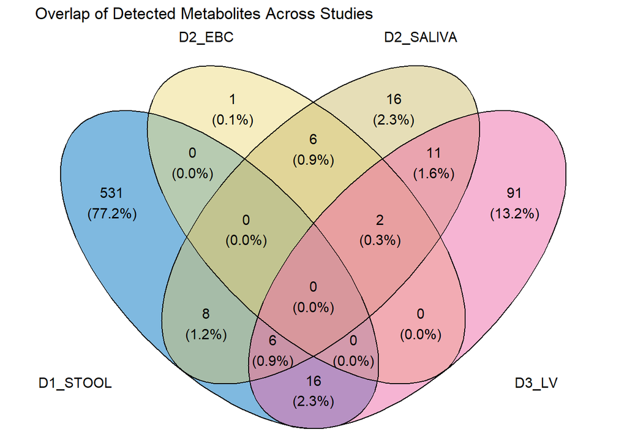

```
## [1] "The following metabolites were detected in both left ventricle hearts and stool of HF."
```

```
##  [1] "Thymidine"                  "Niacinamide"
##  [3] "Glycine"                    "Leucine"
##  [5] "Uracil"                     "Serine"
##  [7] "Purine"                     "Phenylpyruvate"
##  [9] "Taurine"                    "Ornithine"
## [11] "Cytidine"                   "Hypoxanthine"
## [13] "Citrulline"                 "Serotonin"
## [15] "Xanthine"                   "5-hydroxyindoleacetic acid"
## [17] "Spermine"                   "Glucose-6-phosphate"
## [19] "Uridine"                    "Inosine"
## [21] "Adenosine"                  "Xanthosine"
```

```
## [1] "The following metabolites were detected in breath and stool of HF PTs. "
```

```
## character(0)
```

```
## [1] "The following metabolites were detected in saliva and stool oh HF patients. "
```

```
##  [1] "Methylamine"  "Phenol"       "Urea"         "Ethanolamine" "Glycine"
##  [6] "Putrescine"   "Leucine"      "Uracil"       "Creatinine"   "Taurine"
## [11] "Ornithine"    "Hypoxanthine" "Galactose"    "Sucrose"
```

```
## [1] "The following metabolites were detected in saliva and LV. "
```

```
##  [1] "Glucose"       "Hypoxanthine"  "Lactate"       "Pyruvate"
##  [5] "Succinate"     "Taurine"       "Uracil"        "Glycine"
##  [9] "Alanine"       "Proline"       "Valine"        "Isoleucine"
## [13] "Leucine"       "Histidine"     "Phenylalanine" "Tyrosine"
## [17] "Choline"       "Creatine"      "Ornithine"
```

```
## [1] "The following metabolites were detected in breath and LV of HF PTs. "
```

```
## [1] "Lactate"  "Pyruvate"
```

Now we want to plot the same metabolites, but by hf or control for the different studies

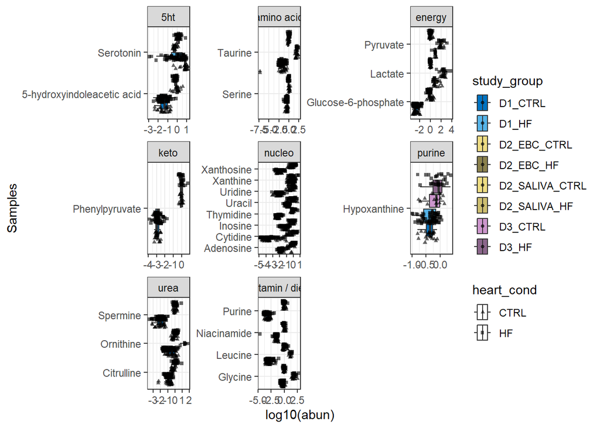

Let’s go ahead and plot the metabolites that overlap between studies so we can see their distribution.

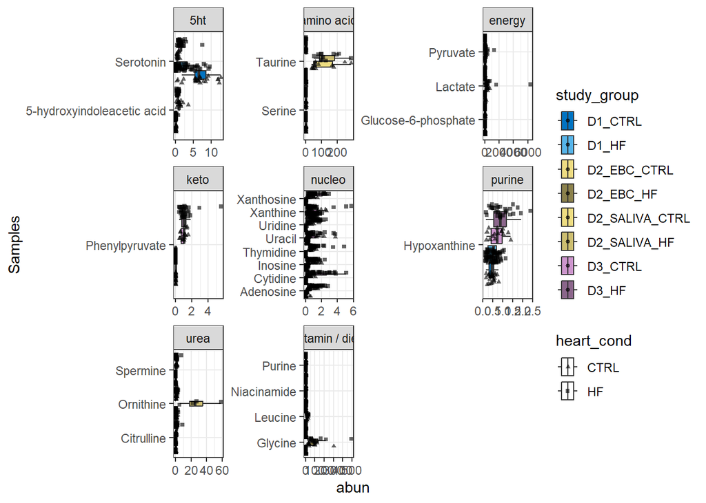

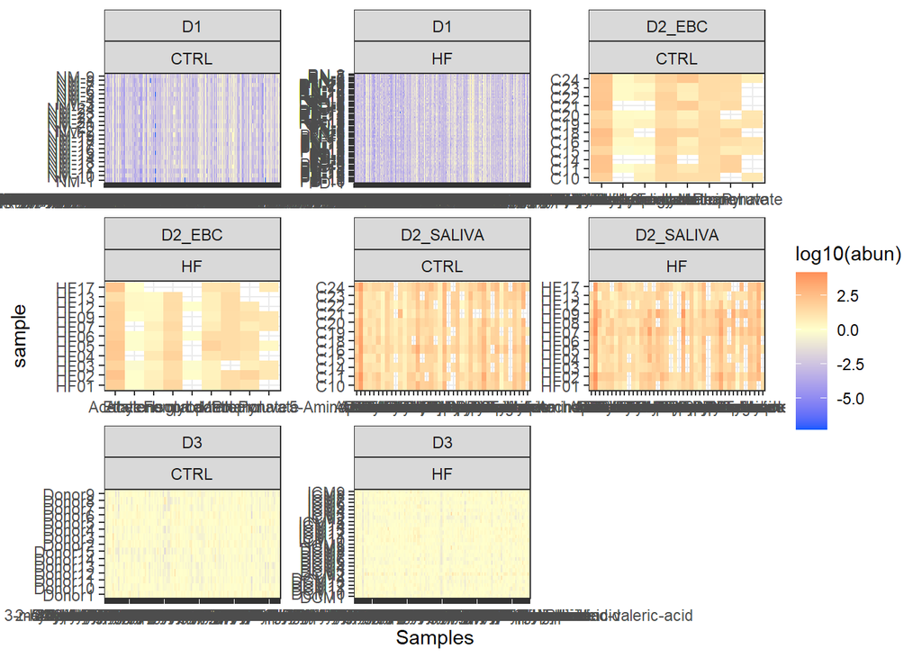

Let’s compare these metabolites to control to see what is up vs down regulated. we want this to be normalized within study so that we can see the degree of difference between studies. I think a log transofrmation is appropriate since we have a lot of values near zero. I thinnkk. We should also compare within-study between group beta dispersions to understand if the within group diversity is similar across groups / organs.

```r
#if(!requireNamespace("BiocManager", quietly = TRUE))
#    install.packages("BiocManager")
#BiocManager::install("Maaslin2")
#library(Maaslin2)
df_input_data<-
  trans_metab %>%
  ungroup() %>%
  select(sample, studyID, abun , heart_cond, Samples) %>%
  distinct() %>%
  #filter(studyID.x == "D3") %>% #$| studyID.y == "D3") %>% ## pairwise comparison
  select(Samples, abun , sample, studyID)%>%
  pivot_wider(names_from = "Samples", values_from = abun , values_fill = 0) %>% arrange(sample)
#metab %>%
df_input_metadata <- minimeta %>%
  ungroup() %>%
   #filter(studyID == "D3" ) %>%#| studyID == "D3") %>%
  mutate(study_group = paste0(studyID, "_",heart_cond))%>% arrange(sample)

# = Maaslin2(input_data     = df_input_data,
#                           input_metadata = df_input_metadata,
#                           normalization  = "NONE",
#                           transform = "LOG",
#                           analysis_method = "LM",
#                           output         = "Maaslin2_d3_lm_NONE_LOG",
#                           fixed_effects  = c("heart_cond"),
#                           reference      = c("heart_cond,CTRL"),
#                           random_effects = c("studyID"),
#                           min_prevalence = 0.001,
#                           min_abundance = 0.0)
## trying with lefse since that is what the depression paper used. should just use d1 if d13 doesn't work to see if i can replicate their results

table(df_input_data$sample %in% df_input_metadata$sample)
table(df_input_metadata$sample %in% df_input_data$sample)
## both 139 so no prob there
#d23_meta %>% filter(analysisID == "D2") %>%

#df_input_data
```

x jk dont look at this because the method wasnt used in the paper

```r
## changfe heart categories :() for d1 only
#df_input_metadata <- df_input_metadata %>%
#  mutate(heart_cond = ifelse(grepl("NM", sample), "CTRL",
#                             ifelse(grepl("RN|PN", sample), "HF",
#                             ifelse(grepl("PD|RD", sample), "HF",
#                             "idk")))) # %>%
#filter(heart_cond == "CTRL|HF")


#dat_lef <- t(df_input_data) ## last two rows
df_short <- df_input_data %>% filter(sample %in%  df_input_metadata$sample) %>% select(-sample)
dat_lef <- t(df_short)
#rownames(dat_lef)

#try to integrate this with the other thing
sampleID <- c("heart_cond")
sampleID <- append(sampleID, df_input_metadata$heart_cond)

studyID <- c("studyID")
studyID <- append(studyID, df_input_metadata$studyID)
#print(sampleID)

fn = "lefse_d_all_norm_input_to_format.txt"
cat(sapply(sampleID, toString), file=fn, sep="\t")
cat("\n", file = fn, append = TRUE)
## add studyID line
cat(sapply(studyID, toString), file=fn, sep="\t", append = TRUE)
cat("\n", file = fn, append = TRUE)
## add data
cat("sampleID\t", file = fn, append = TRUE)
cat(sapply(df_input_data$sample, toString), file=fn, sep="\t", append = TRUE)
cat("\n", file = fn, append = TRUE)
write.table(dat_lef, file = fn, quote=FALSE, row.names=TRUE, append=TRUE, col.names = FALSE, sep = "\t")

#colnames(df_input_data)
```

ok actually limma doesn’t really apply here? meant for rnaseq data, which we don’t have… and not totally clear on how to do the math without other required files which would come with the rna seq data as they are key to data design… idk i think another method is better. unfortuantely probably need to replicate the methods of D1

in d1 on the metab repo they say that they did a PCA with the processed data file that they uploaded to the repo, so I can copy that and see if i am able to produce the same pca plot here.

add ellipses to pca https://www.benjaminbell.co.uk/2018/02/principal-components-analysis-pca-in-r.html

```r
library(broom)  # devtools::install_github("tidymodels/broom")
d1wide <-
  trans_metab %>%
  ungroup() %>%
  select(Samples, abun, sample, studyID)%>%
    #mutate(norm_abun_log10 = as.numeric(norm_abun_log10)) %>%
  pivot_wider(names_from = "Samples", values_from = abun, values_fill = 0 )

d1_pca <-
  trans_metab %>%
  ungroup() %>%
  select(Samples, abun, sample, studyID)%>%
    mutate(norm_abun = as.numeric(abun)) %>%
  pivot_wider(names_from = "Samples", values_from = abun, values_fill = 0 ) %>%
  select(where(is.numeric)) %>% # retain only numeric columns
  prcomp(scale = TRUE) # do PCA on scaled data

#d1wide <- merge(d1wide, minimeta, by = "sample") %>% distinct()
d1wide <- d1wide %>% mutate (study_group = paste0(as.character(studyID), "_",as.character(heart_cond) ))
d1_pca %>%
  augment(d1wide) %>% # add original dataset back in
  ggplot(aes(.fittedPC1, .fittedPC2, color = study_group)) +
  geom_point(size = 1.5) +
 # scale_color_manual(values = c(HF = "#D55E00", CTRL = "#0072B2")  ) +
  theme_half_open(12) + background_grid()+
  stat_ellipse() +scale_color_manual(values = cbbPalette)
#colnames(d1wide)
#dim(d1wide)
#d1wide
#d1_pca$scale

#d1_pca %>%
 # tidy(matrix = "rotation")
# define arrow style for plotting
arrow_style <- arrow(
  angle = 20, ends = "first", type = "closed", length = grid::unit(8, "pt")
)

# plot rotation matrix
d1_pca %>%
  tidy(matrix = "rotation") %>%
  pivot_wider(names_from = "PC", names_prefix = "PC", values_from = "value") %>%
  ggplot(aes(PC1, PC2)) +
  geom_segment(xend = 0, yend = 0, arrow = arrow_style) +
  geom_text(
    aes(label = column),
    hjust = 1, nudge_x = -0.02,
    color = "#904C2F"
  ) +
  #xlim(-1.25, .5) + ylim(-.5, 1) +
  coord_fixed() + # fix aspect ratio to 1:1
  theme_minimal_grid(12)

d1_pca %>%
  tidy(matrix = "eigenvalues") %>%
  ggplot(aes(PC, percent)) +
  geom_col(fill = "#56B4E9", alpha = 0.8) +
  scale_x_continuous(breaks = 1:9) +
  scale_y_continuous(
    labels = scales::percent_format(),
    expand = expansion(mult = c(0, 0.01))
  ) +
  theme_minimal_hgrid(12)+
  xlim(0,10)#+  ylim(0,10)
```

[output not shown]

since i need to do this pca four times, lets write a function for it.

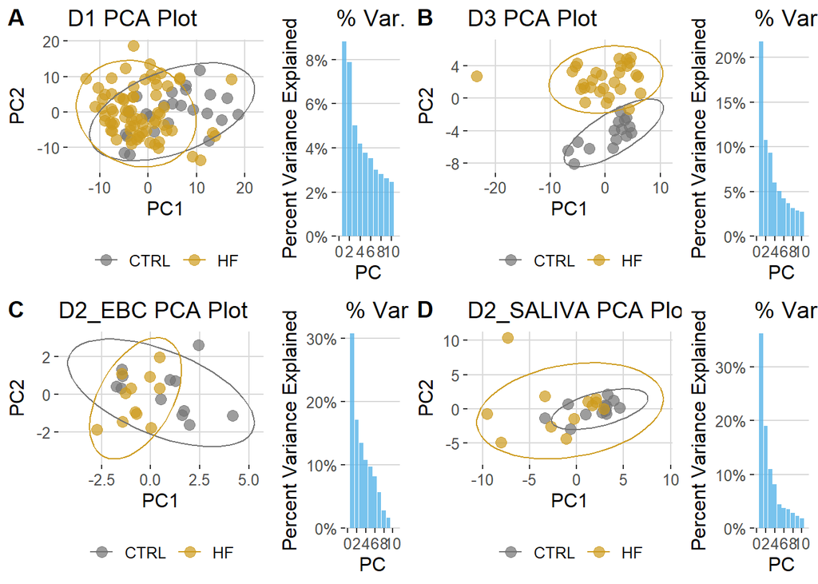

```r
conduct_pca_raw_abun <- function(studyID_filt, main_dat){
  d1wide <- main_dat %>%
    ungroup() %>%
    select(Samples, abun, sample, studyID)%>%
    filter(studyID == studyID_filt)%>%
#    mutate(norm_abun_log10 = as.numeric(.data$norm_abun_log10)) %>%
    pivot_wider(names_from = "Samples", values_from = abun, values_fill = 0 )
 # return(d1wide)

  d1_pca <- main_dat %>%
    ungroup() %>%
    select(Samples, abun, sample, studyID)%>%
    filter(studyID == studyID_filt)%>%
    pivot_wider(names_from = "Samples", values_from = abun, values_fill = 0 ) %>%
    select(where(is.numeric)) %>% # retain only numeric columns
    prcomp(scale = TRUE) # do PCA on scaled data

  d1wide <- merge(d1wide, minimeta, by = "sample", all.x = T) %>% distinct()
  d1wide <- d1wide %>% mutate(study_group = paste0(studyID.x, "_",heart_cond))
  plot_name <- paste0(studyID_filt, " PCA Plot")
  pca_plot <- d1_pca %>%
    augment(d1wide) %>% # add original dataset back in
    ggplot(aes(.fittedPC1, .fittedPC2, color = heart_cond)) +
    geom_point(size = 3, alpha = 0.7) +
    scale_color_manual(values = c(HF = "goldenrod3", CTRL = "grey45")  ) +
    theme_hc(12) + background_grid() +
    labs(title = plot_name, x = "PC1", y = "PC2" ) +
    stat_ellipse() +
    theme(legend.title = element_blank())

  arrow_style <- arrow(    angle = 20, ends = "first", type = "closed", length = grid::unit(8, "pt"))
# plot rotation matrix
  arrow_plot <- d1_pca %>%
    tidy(matrix = "rotation") %>%
    pivot_wider(names_from = "PC", names_prefix = "PC", values_from = "value") %>%
    ggplot(aes(PC1, PC2)) +
    geom_segment(xend = 0, yend = 0, arrow = arrow_style) +
    geom_text(
      aes(label = column),
      hjust = 1, nudge_x = -0.02,
      color = "#904C2F"
    ) +
    #xlim(-1.25, .5) + ylim(-.5, 1) +
    coord_fixed() + # fix aspect ratio to 1:1
   theme_minimal_grid(12) + labs(title = plot_name)

  percent_plot <- d1_pca %>%
    tidy(matrix = "eigenvalues") %>%
    ggplot(aes(as.integer(PC), percent)) +
    geom_col(fill = "#56B4E9", alpha = 0.8) +
    scale_y_continuous(
      labels = scales::percent_format(),
      expand = expansion(mult = c(0, 0.01))
    ) +
    theme_hc(12) +
    labs(title = "% Var.", y = "Percent Variance Explained", x = "PC") +
    #xlim(0,10) # ylim(0,10) +
    scale_x_continuous(limits = c(0, 11), breaks = c(0, 2, 4, 6, 8, 10))

  combo_plot <- plot_grid(pca_plot, percent_plot, rel_widths = c(2, 1))
  #return(pca_plot)
  #return(arrow_plot)
  #return(percent_plot)
  return(combo_plot)
}

p3 <- conduct_pca_raw_abun("D3", main_dat=trans_metab)
#ggsave("pca_w_pv_d3.png", height = 7, width = 10)
p1 <- conduct_pca_raw_abun("D1", main_dat=trans_metab)
#ggsave("pca_w_pv_d1.png", height = 7, width = 10)
#ggsave("d1_raw_abun.png")
p2_ebc <- conduct_pca_raw_abun("D2_EBC", main_dat=trans_metab)
#ggsave("pca_w_pv_d2_ebc.png", height = 7, width = 10)
p2_sal <- conduct_pca_raw_abun("D2_SALIVA", main_dat=trans_metab)
#ggsave("pca_w_pv_d2_saliva.png", height = 7, width = 10)

pca_all <- plot_grid(p1,p3, p2_ebc, p2_sal, ncol = 2, labels = "AUTO", byrow = TRUE)
pca_all
```

```r
ggsave("pca_w_pv_all.png", dpi = 400, height = 10, width = 10)
```

detect significance from pca to see what gets opls-da analysis

```r
## assumes columns are variables/features and rows are sampleIDs / obs

pca_sig_test <- function(studyID_filt, main_dat){

  d1_pca_cat <- main_dat %>%
    ungroup() %>%
    dplyr::select(Samples, abun, sample, studyID, heart_cond)%>%
    filter(studyID == studyID_filt & abun > 0) %>%
    select(-studyID) %>%
    pivot_wider(names_from = "Samples", values_from = abun , values_fill = 0)# %>%select(-Isopropanol)

  d1_pca <- d1_pca_cat %>% dplyr::select(where(is.numeric))
  ## our data is already scales, so not using the below scaling functgion
  #d1_pca_scaled <- scale(d1_pca)
  results <- PCAtest(d1_pca, nboot = 100, nperm = 100, plot = FALSE, counter = FALSE, varcorr = TRUE)

  # adonis/adonis2 not appropriate because it assumed we are working with distance matrices, which we are not?? unless we input the pca itself?
  # <- adonis2(d1_pcaa ~ heart_cond, data = d1_pca_cat, method='eu')
  ## pairwi9se.adonis2() inappropriate here bc assumes working with bray-curtis/microbe data, which we are not.

    ## test pca in UV scaling, produces same results so hashing out (no point of doing it). leaving for future reviewers.
  return(results)
  # inData <- main_dat %>%
  #   ungroup() %>%
  #   filter(studyID == studyID_filt) %>%
  #  dplyr::select(Samples, abun, sample, studyID) %>%
  #uv_mat <- santaR:::scaling_UV(inData)
  #result2 <- PCAtest(uv_mat, nboot=100, nperm=100, plot = TRUE)
  ## produces identical results, leaving here only if a reviewer wants to test or see with a scaling method
}

#pca_sig_test("D2_SALIVA", trans_metab)
#pca_sig_test("D3", trans_metab)
#pca_sig_test("D1", trans_metab)
#pca_sig_test("D2_EBC", trans_metab)#

univariate_testing <- function(studyID_filt, main_dat){
    y = data.frame("pval", "metabolite", "studyID", "adj_pval_fdr")
    colnames(y) <- c("pval", "metabolite", "studyID", "adj_pval_fdr")
    smol_dat <- main_dat %>%
        ungroup() %>%
        filter(studyID == studyID_filt)
    metab_list <- as.list(unique(smol_dat$Samples))

    for (i in metab_list) {
      new_line = data.frame("pval", "metabolite", "studyID", "adj_pval_fdr")
      univar_testing <- smol_dat %>%
        filter(Samples == i ) %>%
        distinct() %>%
        mutate(heart_cond = as.factor(heart_cond)) #%>%filter(length( forcats::fct_unique(heart_cond)) == 2)
        ## something to confirm two levels of factor
      if (length( forcats::fct_unique(univar_testing$heart_cond)) == 2) {
        x_abun <- univar_testing$abun
        y_heart_cond <- univar_testing$heart_cond
        w <- wilcox.test(x_abun ~ y_heart_cond, alternative = "two.sided", exact = TRUE)
        new_line$pval <- as.numeric(w$p.value)
        new_line$metabolite <- i
        new_line$studyID <- studyID_filt
        new_line <- new_line %>% select(pval, metabolite, studyID) %>%
          mutate(adj_pval_fdr = p.adjust(pval, method = "fdr", n = length(metab_list)))
        y <- rbind(y, new_line)
      }
    }
  ## after math add info to file
  fname = paste0("univariate_testing_", studyID_filt, ".txt")
  write.table(y, file = fname, append = FALSE, quote = FALSE, row.names = FALSE, sep = "\t")
}
#wilcox_test(formula = abun ~ heart_cond, alternative = "two.sided", data = trans_metab)

univariate_testing("D2_SALIVA", trans_metab)
```

[output not shown]

```r
univariate_testing("D2_EBC", trans_metab)
univariate_testing("D3", trans_metab)
univariate_testing("D1", trans_metab)
```

now that we have generated univariate statistics, lets do the classic volcANo plot

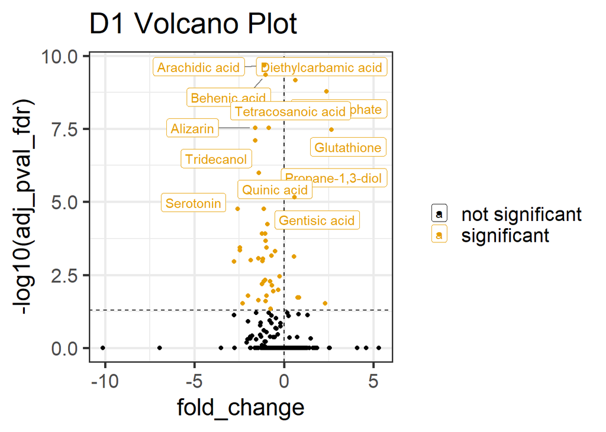

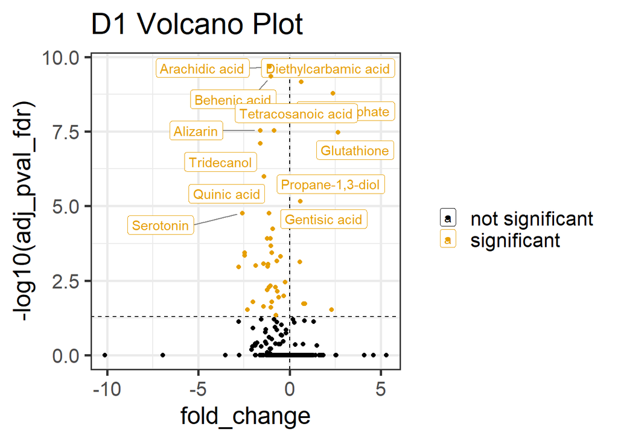

```r
make_volc_plots <- function(studyID_filt, main_dat){
  fname = paste0("univariate_testing_", studyID_filt, ".txt")
  d <- read.csv(file =fname, sep = "\t", skip = 1, row.names = NULL)

  d_sig <- d %>% filter(adj_pval_fdr < 0.05)
  sig_metas <- main_dat %>%
    filter(studyID ==  studyID_filt) %>%
    filter(Samples %in% d_sig$metabolite) %>%
    ggplot(aes(x = heart_cond, y = abun, fill = heart_cond)) +
    geom_boxplot(outlier.shape = NA, alpha = 0.5) +
    geom_jitter(height = 0, width = 0.2, alpha = 0.7) +
    theme_bw() +
    scale_fill_manual(values = cbbPalette) +
    facet_wrap(.~Samples, scales = "free") +
    labs(title = paste0("Significant Metabolites, ", studyID_filt)) +
    theme_set(theme_bw(base_size=20))

  plotname = paste0("significant_metabolites_", studyID_filt, ".png")
  ggsave(plotname, height = 15, width = 20, plot = sig_metas)

  #volcano plot??
  volc_plot <- main_dat %>%
    filter(studyID == studyID_filt) %>%
    #ungroup() %>%
    group_by(heart_cond, Samples) %>%
    summarise(value = median(abun) ) %>%
    pivot_wider(names_from = heart_cond, values_from = value, values_fill = 0.000001) %>%
    mutate(fold_change = log2(HF) - log2(CTRL)) %>%
    mutate(label_info = ifelse(fold_change %in% top_n(x = ., n = 10, wt = fold_change), "top10", " ")) %>%
    merge(d, by.x = "Samples", by.y = "metabolite") %>%
    mutate(signi = ifelse(Samples %in% d_sig$metabolite, "significant", "not significant"))%>%
    ggplot(aes(x = fold_change, y = -log10(adj_pval_fdr), color = signi)) +
    scale_color_manual(values = cbbPalette) +
    labs(title = paste0(studyID_filt," Volcano Plot"), color = " ") +
    theme_pubclean()  +
    geom_vline(xintercept=c(0), linetype = "dashed") +
    geom_hline(yintercept=-log10(0.05), linetype = "dashed") +
    #geom_text(aes(label=ifelse(label_info=="top10",as.character(Samples),'')),hjust=0,vjust=0)
    geom_label_repel(aes(label = Samples),
                  box.padding   = 0.35,
                  point.padding = 0.5,
                  segment.color = 'grey50',
                  max.overlaps = 15) +
    theme_set(theme_pubclean(base_size=20))+
    geom_point()# +
    #scale_x_continuous(expand = expansion(add = 0.5)) +
    #scale_y_continuous(expand = expansion(add = c(0,3)))

  print(volc_plot)
  plot2name = paste0("volcanoplot_", studyID_filt, ".png")
  ggsave(plot2name, plot = volc_plot)
  #print(d_sig)
  print(volc_plot)
}

v1 <- make_volc_plots("D1", trans_metab)
```

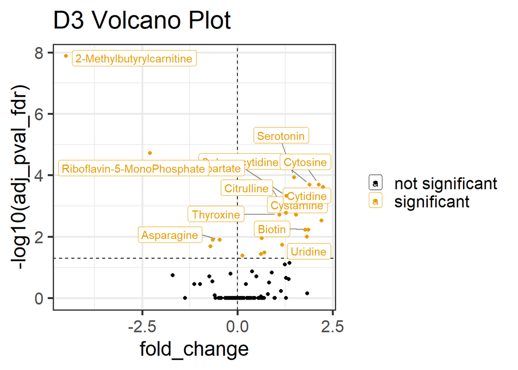

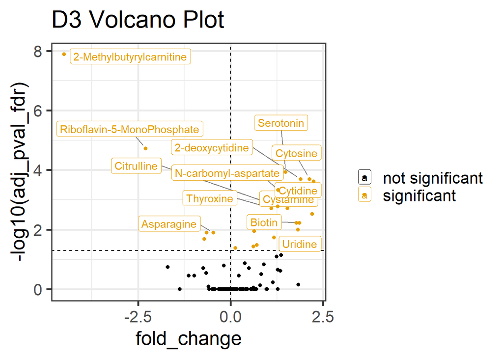

```r
v3 <- make_volc_plots("D3", trans_metab)
```

[figure not shown]

```r
plot_grid(v1,v3, ncol = 2, labels = "AUTO")
```

```r
#trans_metab
#make_volc_plots("D2_EBC", trans_metab)
# make_volc_plots("D2_SALIVA", trans_metab)
## d2 studies have no sig after adjustment so not running
```

opls-da is a supervised machine leanring method

```
## PCA
## 44 samples x 126 variables
## standard scaling of predictors
##       R2X(cum) pre ort
## Total    0.529   5   0
```

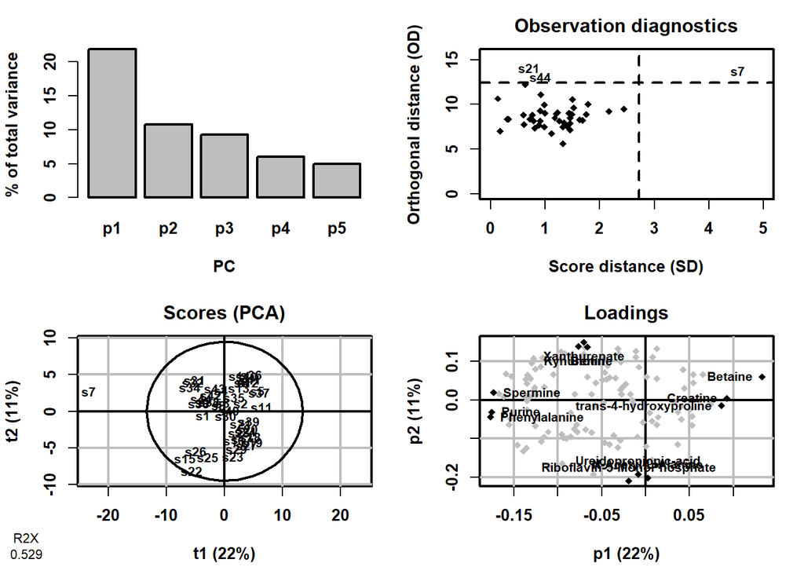

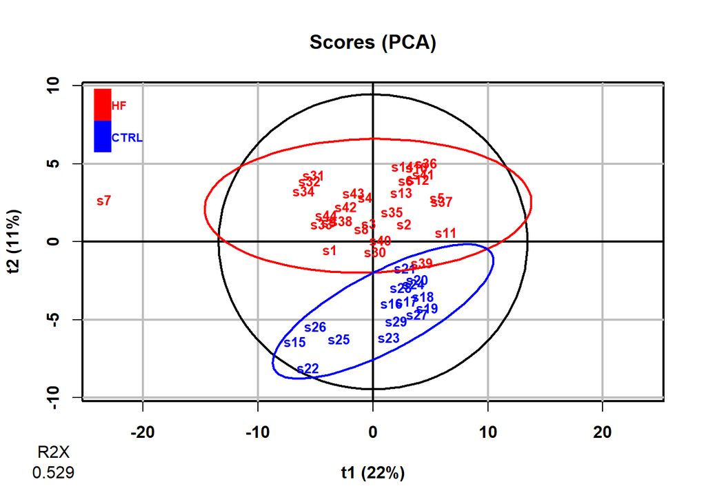

```
## OPLS-DA
## 44 samples x 126 variables and 1 response
## standard scaling of predictors and response(s)
##       R2X(cum) R2Y(cum) Q2(cum) RMSEE pre ort pR2Y  pQ2
## Total    0.312    0.893   0.808 0.161   1   1 0.05 0.05
```

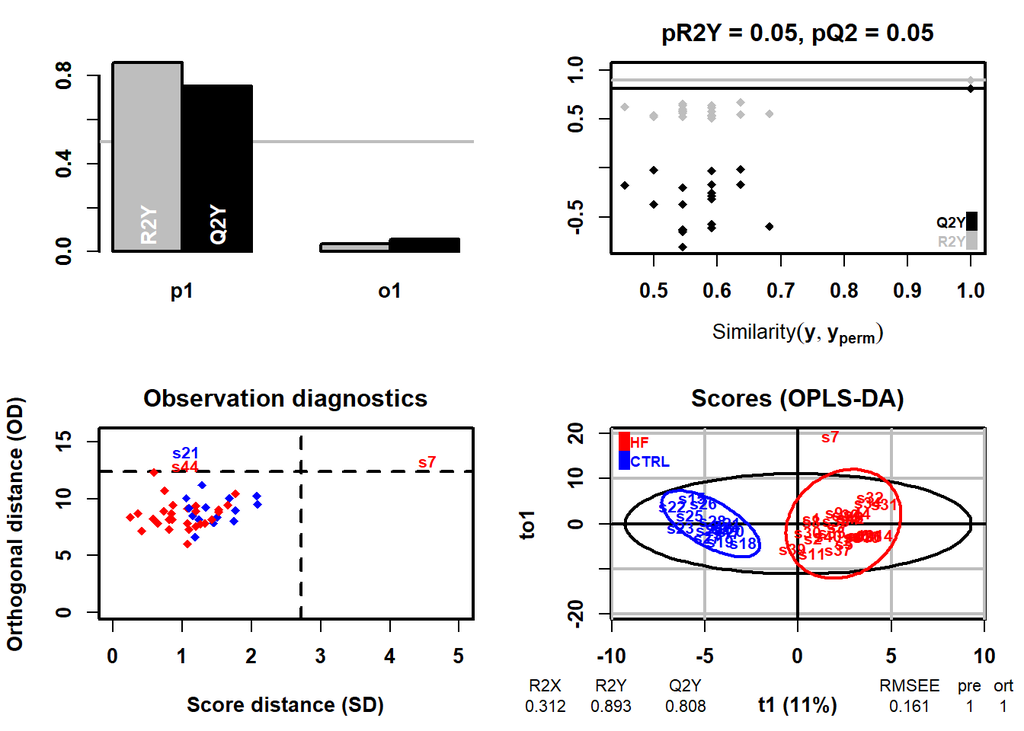

```
## OPLS-DA
## 44 samples x 126 variables and 1 response
## standard scaling of predictors and response(s)
##       R2X(cum) R2Y(cum) Q2(cum) RMSEE pre ort pR2Y  pQ2
## Total    0.312    0.893   0.808 0.161   1   1 0.05 0.05
```

```r
minimeta <- rbind(minimeta,
      minimeta %>%
        filter(studyID == "D2") %>%
        mutate(studyID = "D2_SALIVA"))

minimeta <- rbind(minimeta,
      minimeta %>%
        filter(studyID == "D2") %>%
        mutate(studyID = "D2_EBC"))

conduct_oplsda <- function(studyID_filt, main_dat){
  metab_wide <- main_dat %>%
    ungroup() %>%
    pivot_wider(names_from = Samples, values_from = abun, values_fill = 0)

  inMeta <- minimeta %>% filter(studyID == studyID_filt & sample %in% metab_wide$sample) %>% arrange(sample) %>% select(-studyID)
  colnames(inMeta) <- c("ind", "group")

  ## prep dataframe
  inData <-
    metab %>% ungroup() %>% filter(studyID == studyID_filt) %>%
    dplyr::select(Samples, abun, sample, studyID) %>%
         distinct() %>%
    filter(sample %in% inMeta$ind) %>%
    #  group_by(sample, Samples) %>%
    #    filter(n()>1)
        mutate(sample = paste0(sample, "_", studyID)) %>%
      pivot_wider(names_from = "Samples", values_from = "abun") %>%
    ungroup() %>%
      dplyr::select(-studyID, -sample) #%>%  arrange(sample)

  opls.pca <- opls(inData)
  vect_y <- inMeta$group
  plot(opls.pca,
       typeVc = "x-score",
       parAsColFcVn = vect_y)

  hf.plsda <- opls(inData, vect_y, predI = 1, orthoI = NA)
  return(hf.plsda)
}## prep inMeta for RDS

conduct_oplsda("D3", trans_metab)
```

```r
conduct_oplsda("D1", trans_metab)
```

```
## PCA
## 95 samples x 561 variables
## standard scaling of predictors
##       R2X(cum) pre ort
## Total    0.441  10   0
```

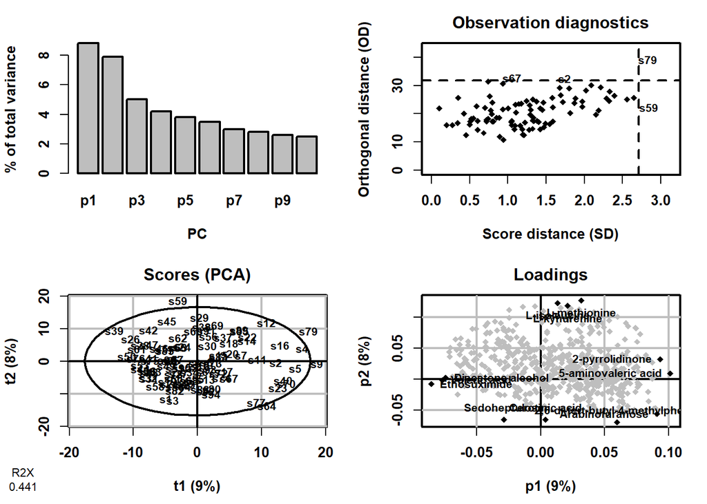

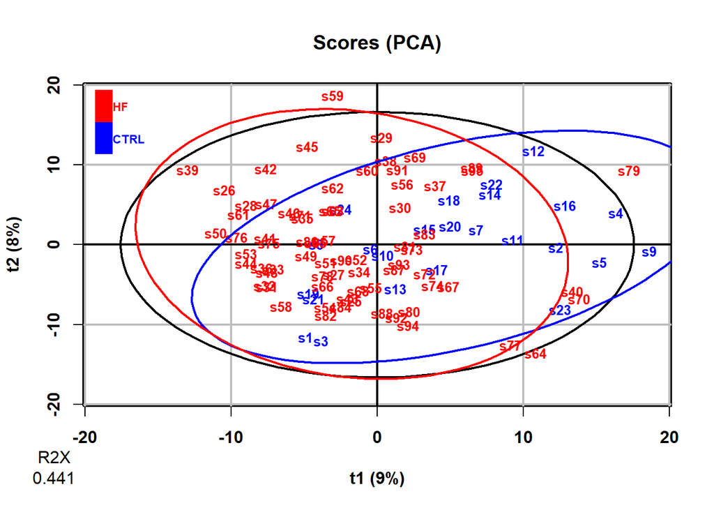

```
## OPLS-DA
## 95 samples x 561 variables and 1 response
## standard scaling of predictors and response(s)
##       R2X(cum) R2Y(cum) Q2(cum)  RMSEE pre ort pR2Y  pQ2
## Total    0.229    0.978   0.734 0.0665   1   4 0.05 0.05
```

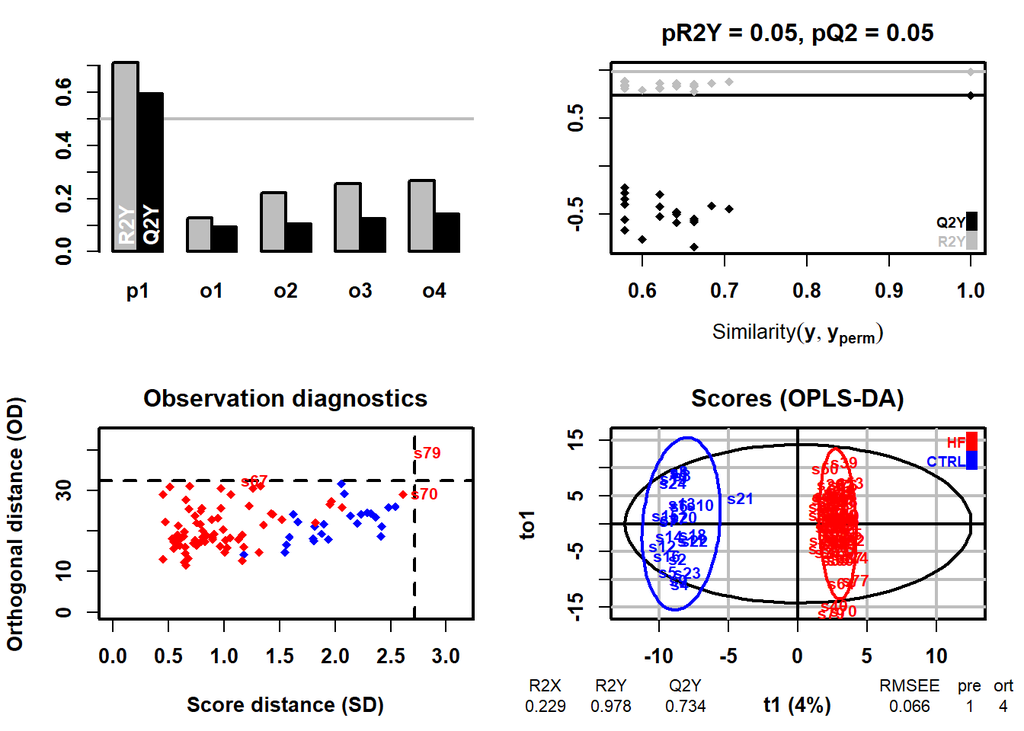

```
## OPLS-DA
## 95 samples x 561 variables and 1 response
## standard scaling of predictors and response(s)
##       R2X(cum) R2Y(cum) Q2(cum)  RMSEE pre ort pR2Y  pQ2
## Total    0.229    0.978   0.734 0.0665   1   4 0.05 0.05
```

alrighty. we have done the univariate testing and I have created the categories of what each of those things is doing. lets read in that data and see how those things look across our control and heart failure patients.

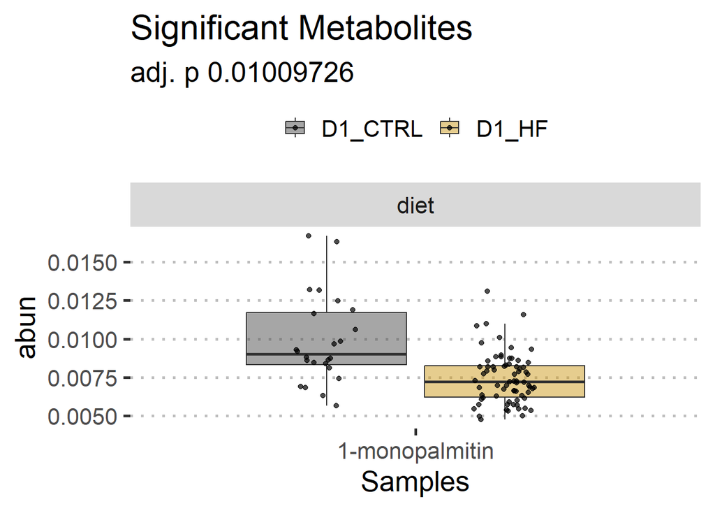

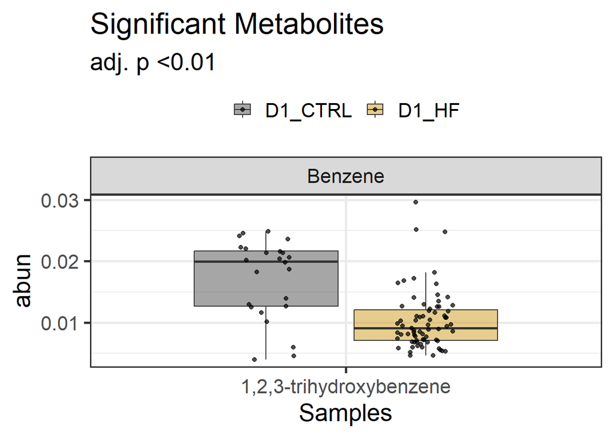

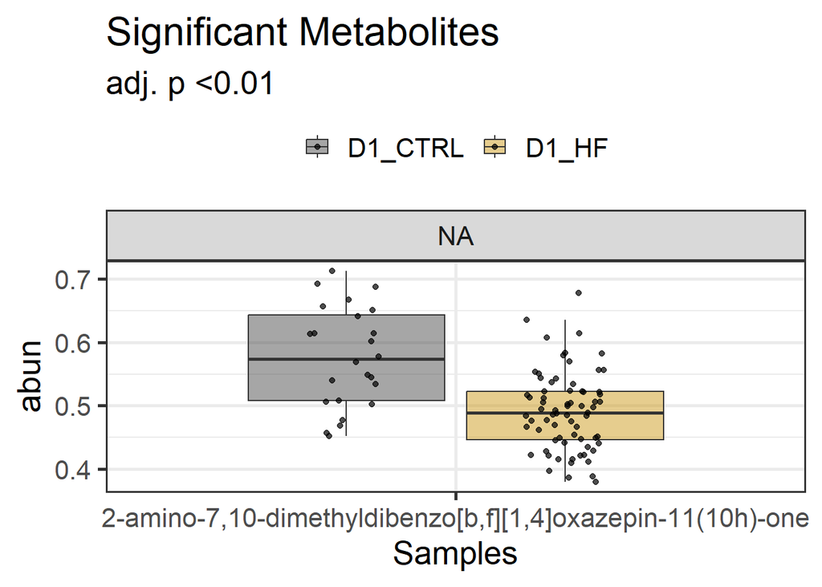

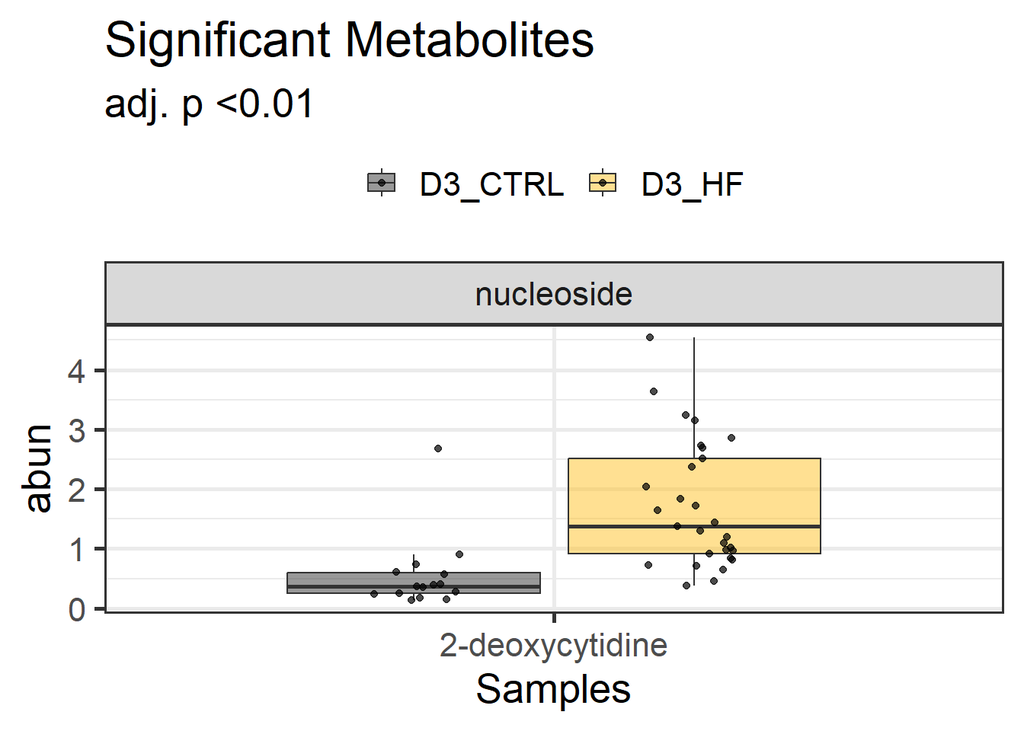

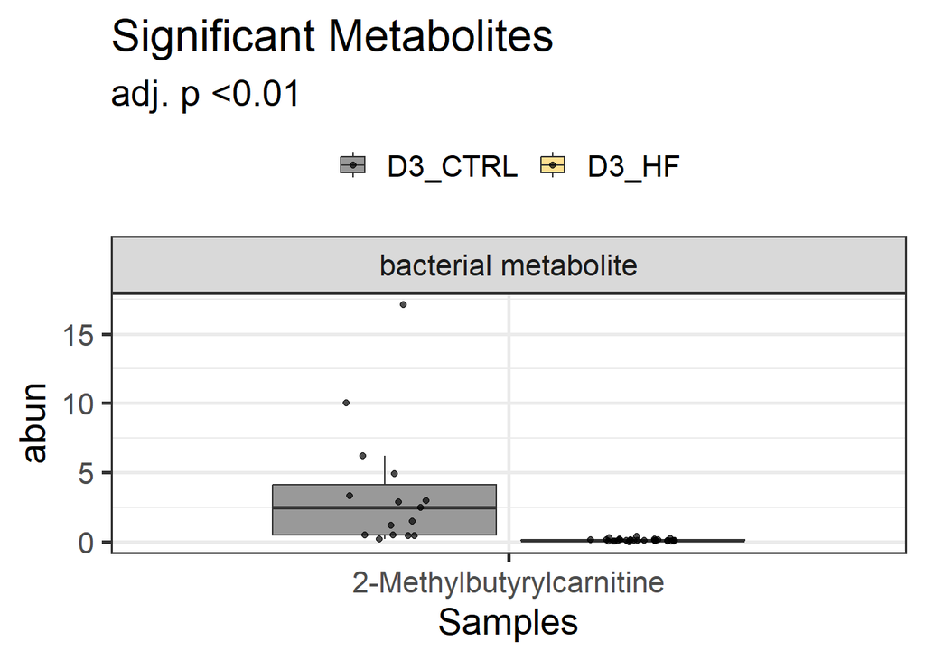

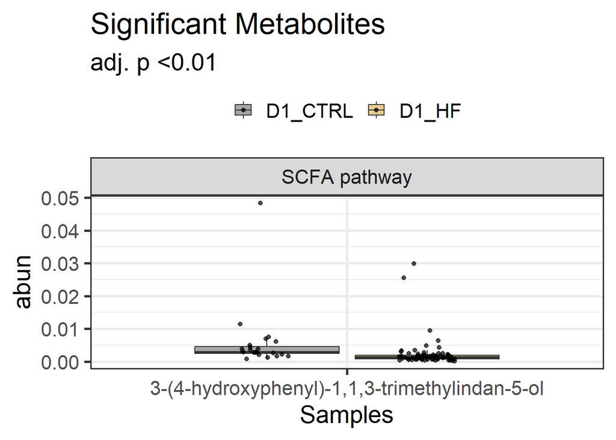

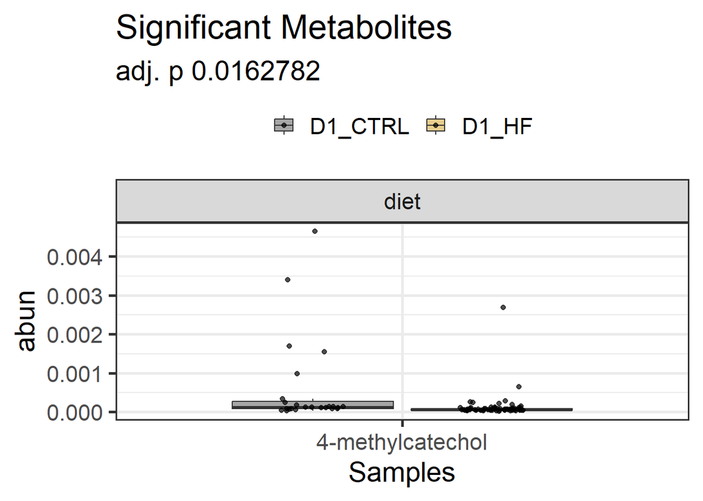

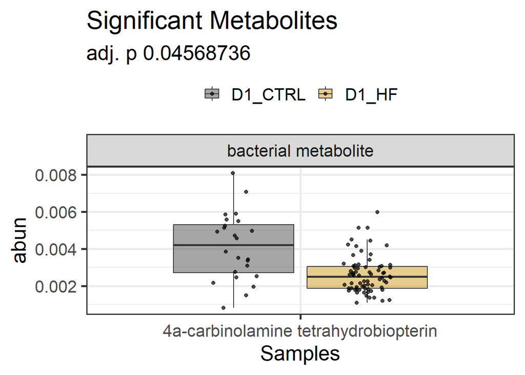

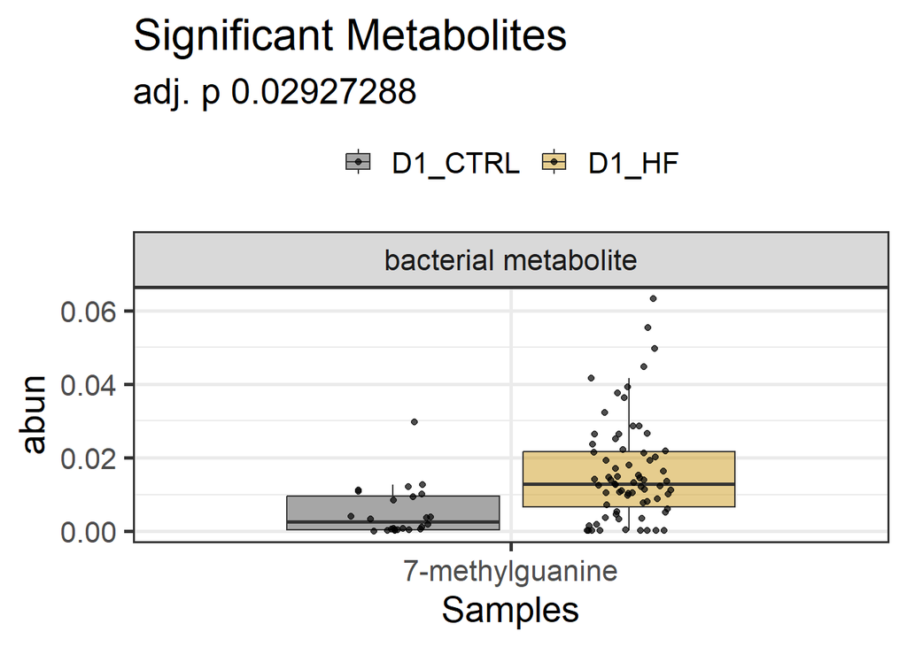

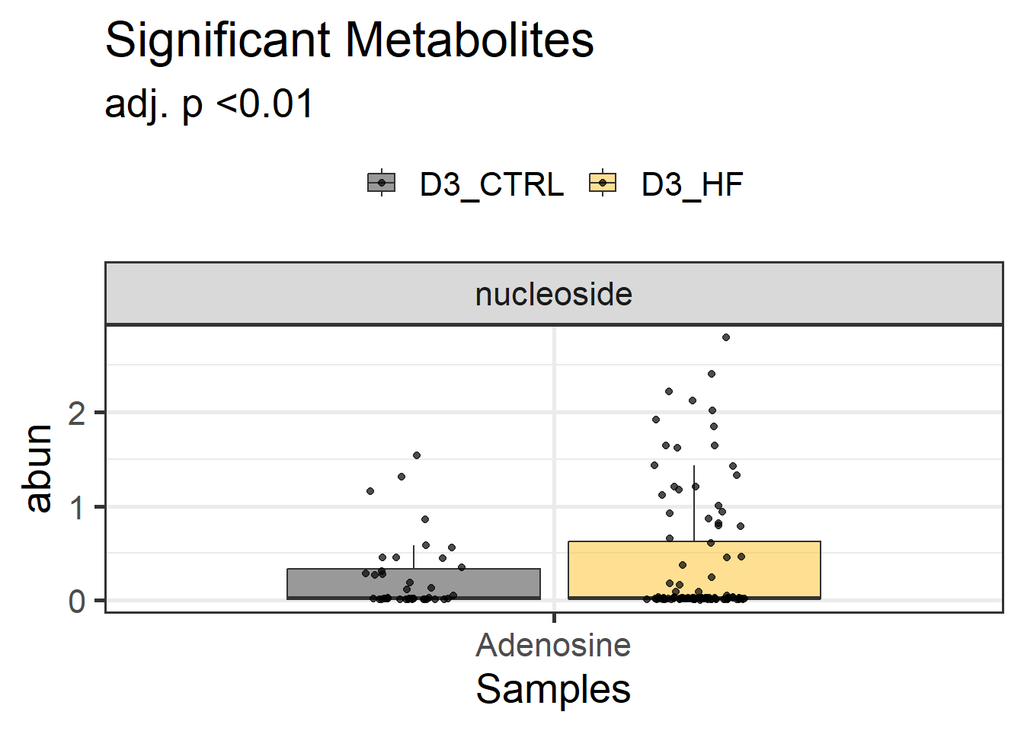

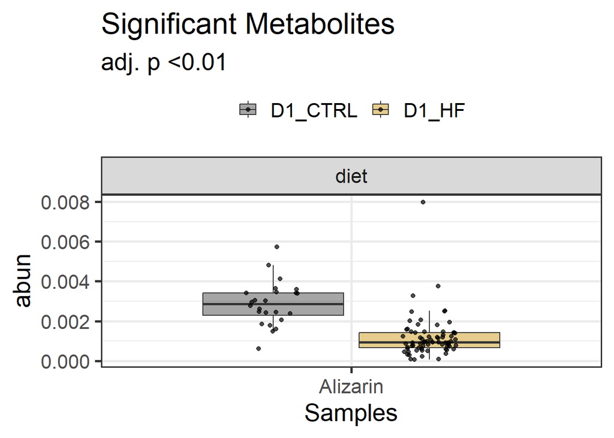

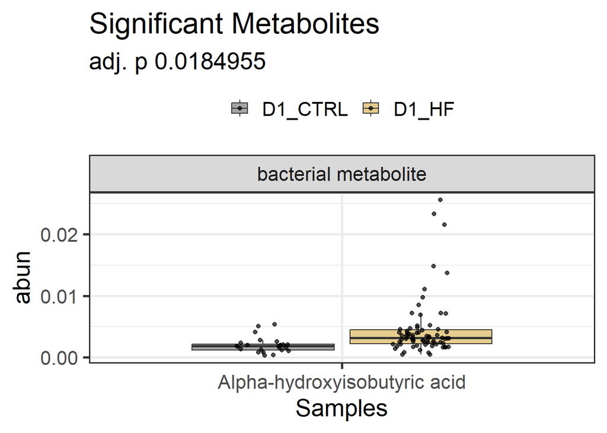

[50 more figures not shown]

```r
cats <- read.csv("sig_metabolites_univariate_analysis_fdr - Sheet1.csv")
## merge categories for abundances for some plotting

unidat <- metab %>%
  select(sample, Samples, abun, studyID, heart_cond) %>%
  merge(cats, metab, by.y = "metabolite", by.x = "Samples") %>%
  filter(!grepl("QC", sample)) %>%
  mutate(study_group = as.factor(paste0(studyID.y, "_", heart_cond)))

unidat$studyID = unidat$studyID.x
unidat <- unidat %>% select(-studyID.x, -studyID.y) %>% mutate(adj.p = ifelse(adj_pval_fdr >= 0.01, adj_pval_fdr, "<0.01"))

for (i in unique(unidat$Samples)) {
  textdat <- unidat %>%
    filter(Samples == i) %>%
    select(adj.p, study_group)

  a <- unidat %>%
    filter(Samples == i) %>%
    ggplot(aes(x = Samples, y = abun, fill = study_group)) +
    geom_boxplot(outlier.shape = NA, alpha = 0.5) +
    geom_point(position = position_jitterdodge(), alpha = 0.7)+
    theme_bw() +
    facet_wrap(.~pathway, scales = "free") +
    labs(title = paste0("Significant Metabolites")) +
    theme_set(theme_bw(base_size=20))+
    scale_fill_manual(values = c("D1_CTRL" = "grey30",
                                "D3_CTRL" = "grey20",
                                "D1_HF" = "goldenrod3",
                                "D3_HF" = "goldenrod1")) +
    #geom_text(data = textdat, aes(x = 1.5, y = 0, label = paste0("adj. p ", adj.p)))
    labs(subtitle = paste0("adj. p ", textdat$adj.p), size = 5) +
    theme(legend.position = "top", legend.title = element_blank())

  print(a)
  fname = paste0("univariate_sig_plots/",i, ".png" )
  ggsave(plot=a, filename=fname, dpi = 300, height = 7, width = 5)

}
```